# My hint: Seaborn palettes and colors

### hls_palette & husl_palette

Если "тяжелых" элементов слишком много, т.е. очень много категорий в данных, то самый простой способ их различать, не выделяя ни одной из них - это использовать круговые палитры. Круговая палитра - это палитра цвета в которой меняются в циклическом пространстве цветов с сохранением яркости и насыщенности. Самый простой способ создания таких палитр - это применение пространства hls:

If there are too many "heavy" elements, i.e. there are a lot of categories in the data, then the easiest way to distinguish them without highlighting any of them is to use circular palettes. A circular palette is a palette of colors in which colors change in a cyclic space while maintaining brightness and saturation. The easiest way to create such palettes is to use the hls space:

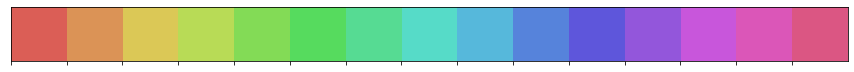

```python
sns.palplot(sns.color_palette('hls', 15))
```

Если нужно контролировать яркость и насыщенность цветов, то можно воспользоваться функцией hls_palette():

If you need to control the brightness and saturation of colors, you can use the hls_palette() function:

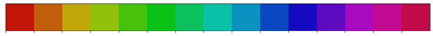

```python
sns.palplot(sns.hls_palette(15, l=0.4, s=0.9))
```

Однако, использование hls все же допускает выделение элементов, так как для нашей зрительной системы желтый цвет кажется более ярким чем синий. Если нужно гарантированно "сгладить" все элементы, то лучше воспользоваться системой husl (HSLuv):

However, the use of hls still allows for the selection of elements, since for our visual system, yellow seems brighter than blue. If you need to "smooth out" all the elements with a guarantee, it is better to use the husl (HSLuv) system:

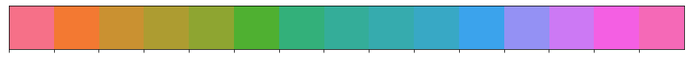

```python
sns.palplot(sns.color_palette('husl', 15))
```

Как видите, насыщенность и яркость в данной палитре выглядит гораздо равномернее. Если нужен более гибкий доступ к этой системе цветов, то можно воспользоваться функцией husl_palette():

As you can see, the saturation and brightness in this palette looks much more uniform. If you need more flexible access to this color system, you can use the husl_palette() function:

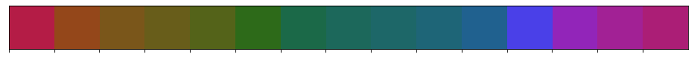

```python
sns.palplot(sns.husl_palette(15, l=0.4, s=0.9))
```

### cubehelix_palette

В случаях, очень большого количества градаций, черно белой печати или дальтонизма, последовательные палитры могут передавть числовую информацию не вполной мере. Что бы избежать этого, можно воспользоваться цветовой системой cubehelix с линейным изменением яркости и оттенка. В Matplotlib имеется собственная палитра cubehelix:

In cases of a very large number of gradations, black-and-white printing or color blindness, sequential palettes may not fully convey numerical information. To avoid this, you can use the cubehelix color system with a linear change in brightness and hue. Matplotlib has its own cube helix palette:

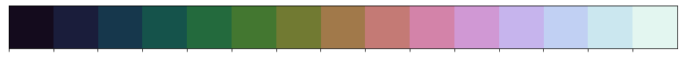

```python
sns.palplot(sns.color_palette('cubehelix', 15))
```

В Seaborn данная палитра изменена так, что оттенок меняется гораздо слабее интенсивности:

In Seaborn, this palette has been changed so that the shade changes much weaker than the intensity:

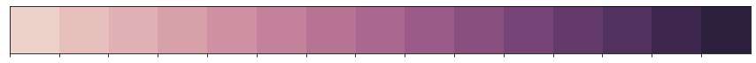

```python
sns.palplot(sns.cubehelix_palette(15))
```

Функция cubehelix_palette() позволяет настраивать данную палитру, например, можно задать начальный цвет (значения из интервала [0; 3]) и поворот в системе оттенков:

The cubehelix_palette() function allows you to customize this palette, for example, you can set the initial color (values from the interval [0; 3]) and rotation in the hue system:

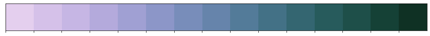

```python
sns.palplot(sns.cubehelix_palette(15, start=2, rot=0.5))
```

Можно даже контролировать, то насколько яркими и темными будут крайние значения палитры и поворот самой палитры:

You can even control how bright and dark the extreme values of the palette and the rotation of the palette itself will be:

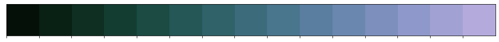

```python
sns.palplot(sns.cubehelix_palette(15, start=2, rot=0.5, dark=0.05, light=0.7, reverse=True))
```

### ColorBrewer

Инструмент [ColorBrewer](https://colorbrewer2.org/#type=sequential&scheme=BuGn&n=7) является хорошим источником палитр, но помимо этого он так же дает некоторые рекомендации по поводу того, какая палитра для какой ситуации лучше всего подходит.

The ColorBrewer tool is a good source of palettes, but beyond that it also gives some recommendations about which palette is best suited for which situation.

## Separate colors and their names in Seaborn

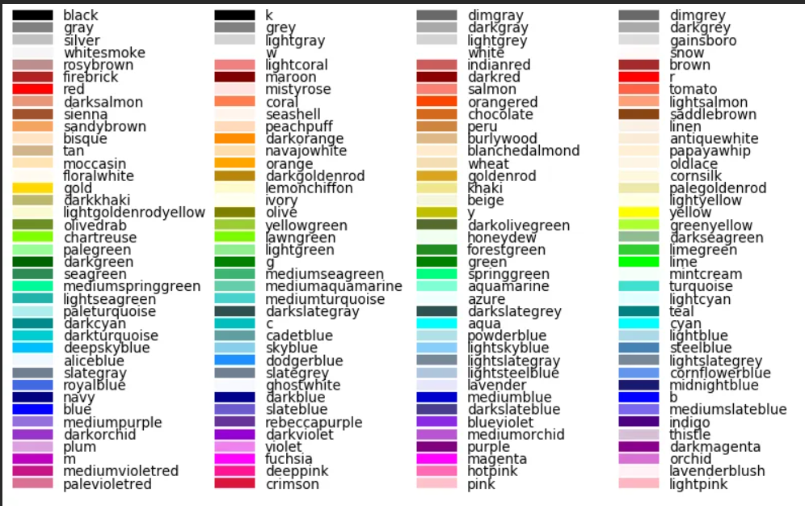

## Types of charts

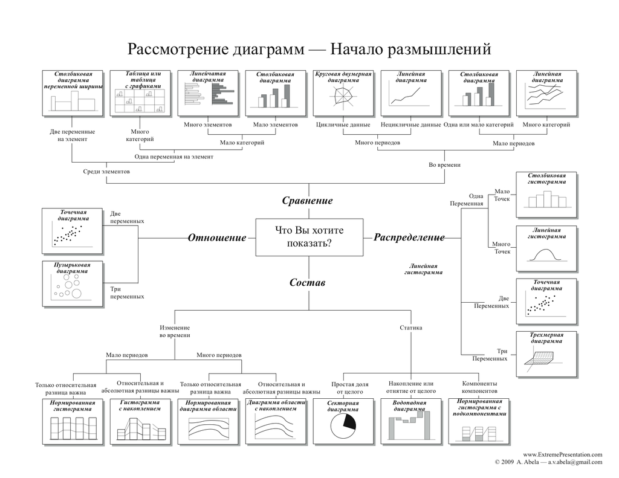

## List of available plt.styles

```python
print(plt.style.available)
```

[output not shown]

Как использовать:

How to use:

```python
plt.style.use('seaborn-whitegrid')
```

Как увеличить размер шрифта:

How to increase the font size:

```python
sns.set(font_scale=1.5)
```

Для того, чтобы посмотреть стили на примерах, нам понадобится небольшой датафрейм:

In order to see the styles in the examples, we will need a small dataframe:

```python
data = {'day_name': ['Monday', 'Tuesday', 'Wednesday', 'Thursday', 'Friday', 'Saturday', 'Sunday'],
        'day_number': [1, 2, 3, 4, 5, 6, 7]}

df = pd.DataFrame(data)
```

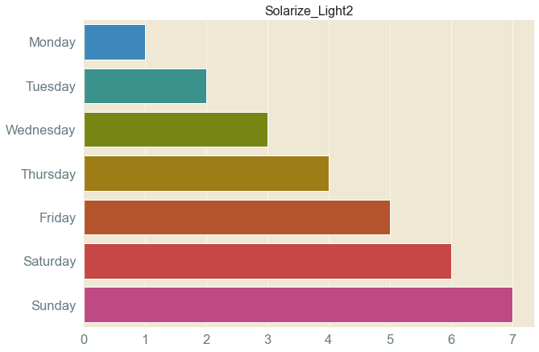

```python
plt.figure(figsize= (10, 7))
plt.style.use('Solarize_Light2')
sns.barplot(x='day_number', y='day_name', data=df)
plt.title('Solarize_Light2')
plt.xlabel('')
plt.ylabel('')
plt.show();
```

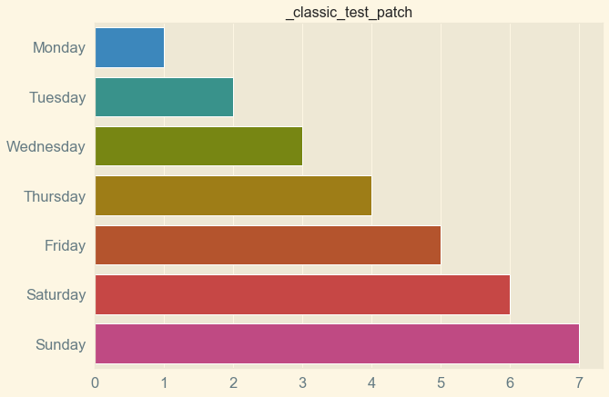

```python
plt.figure(figsize= (10, 7))
plt.style.use('_classic_test_patch')
sns.barplot(x='day_number', y='day_name', data=df)
plt.title('_classic_test_patch')
plt.xlabel('')
plt.ylabel('')
plt.show();
```

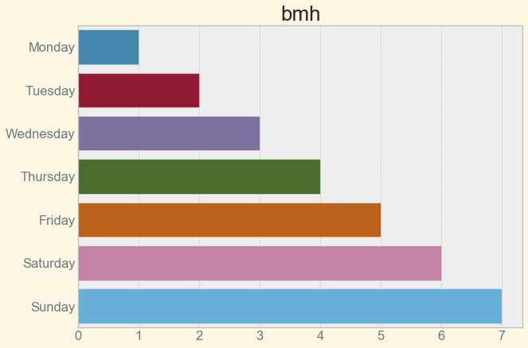

```python
plt.figure(figsize= (10, 7))
plt.style.use('bmh')
sns.barplot(x='day_number', y='day_name', data=df)
plt.title('bmh')
plt.xlabel('')
plt.ylabel('')
plt.show();
```

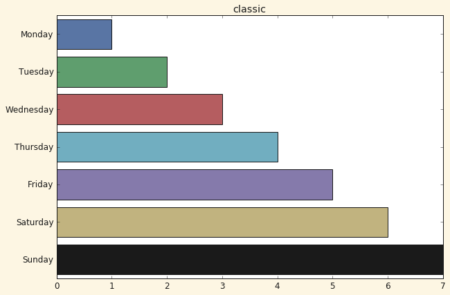

```python
plt.figure(figsize= (10, 7))
plt.style.use('classic')
sns.barplot(x='day_number', y='day_name', data=df)
plt.title('classic')
plt.xlabel('')
plt.ylabel('')
plt.show();
```

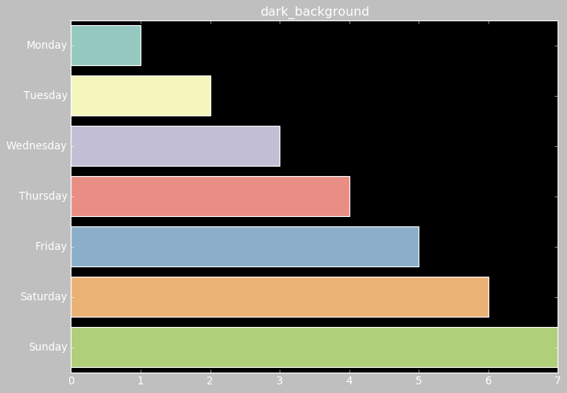

```python
plt.figure(figsize= (10, 7))
plt.style.use('dark_background')
sns.barplot(x='day_number', y='day_name', data=df)
plt.title('dark_background')
plt.xlabel('')
plt.ylabel('')
plt.show();
```

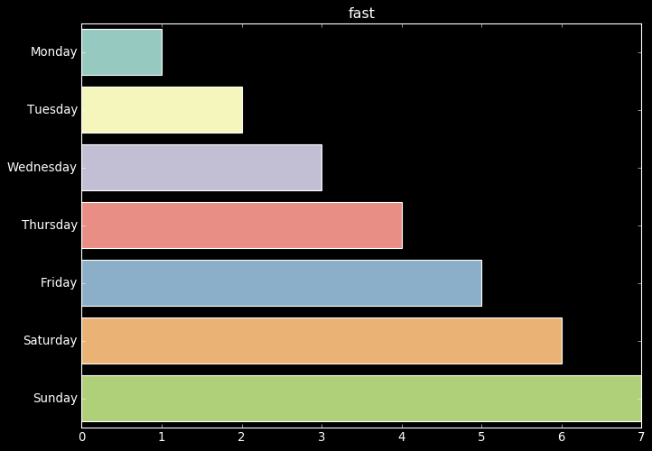

```python
plt.figure(figsize= (10, 7))
plt.style.use('fast')
sns.barplot(x='day_number', y='day_name', data=df)
plt.title('fast')
plt.xlabel('')
plt.ylabel('')
plt.show();
```

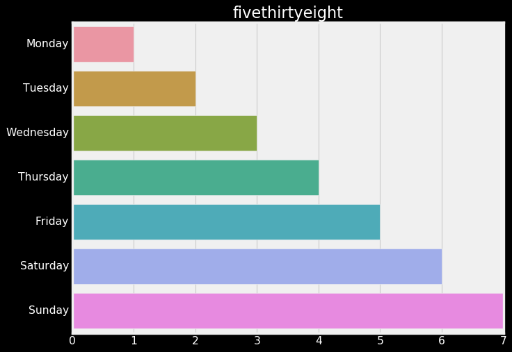

```python
plt.figure(figsize= (10, 7))
plt.style.use('fivethirtyeight')
sns.barplot(x='day_number', y='day_name', data=df)
plt.title('fivethirtyeight')
plt.xlabel('')
plt.ylabel('')
plt.show();
```